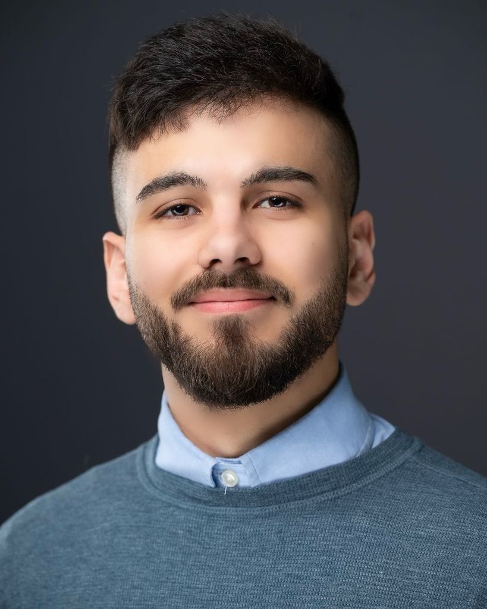

# Matheus de Barros

## Bio

I am a quantitative fisheries scientist focusing on ecological modelling, fisheries stock assessment, management strategy evaluation, and bayesian statistics. Currently, I’m a PhD research fellow at the School of Aquatic and Fishery Sciences, UW Seattle, where I strive to improve Pacific herring management using simulation modelling. My research is guided by the belief that a sustainable future can be achieved by the correct, coordinated, and evidence-based assessment and management of our renewable and productive fisheries resources.

## Education

**B.S. in Biological Sciences** | Universidade Federal de Alagoas (UFAL), Brazil

**MSc in Marine Sciences** | University of South Alabama, United States

**[Ongoing] PhD in Aquatic and Fishery Sciences** | University of Washington, United States

## Experience

**Environmental Consultant** | Brazilian Ministry of the Environment | June 2024 - Present

**Environmental Consultant** | Alagoas State Secretary of Fisheries | August 2024 - Present

**Undergraduate Research Fellow** | Universidade Federal de Alagoas (UFAL), Brazil | September 2018 - February 2022

**Graduate Research Assistant** | Stokes School of Marine and Environmental Sciences, University of South Alabama, United States | May 2022 - May 2024